Title: “Mysample”  
Author: “Gaurish Bansal”  
Date: “2022-09-14”  
Output: html_document

## Welcome to this Sample Document

## Solving quadratic equations

Considering equations of the form $ax^2+bx+c=0$. This is a quadratic equation; changing the values of $a$, $b$, and $c$, changes the shape of the quadratic. There are two solutions to a quadratic equation:

$$x=\dfrac{-b \pm \sqrt{b^2-4ac}}{2a}$$

Let’s draw a quadratic curve for different values of $a$, $b$, and $c$.

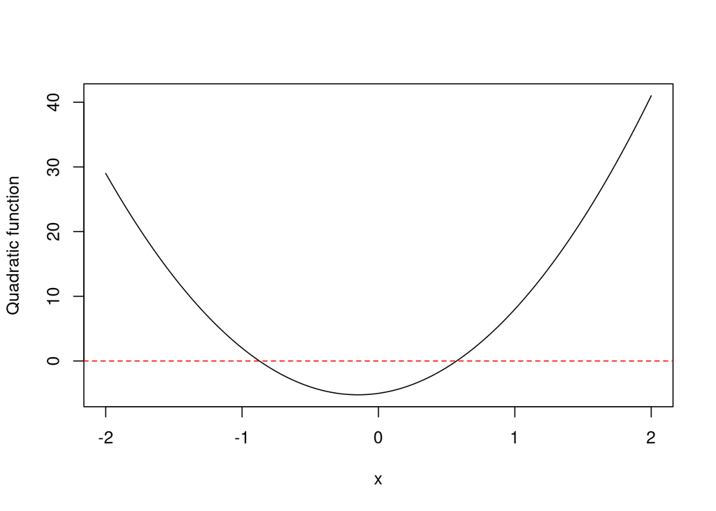

```r
a <- 10
b <- 3
c <- -5
x <- seq(-2, 2, length = 1e3)
fx <- a*x^2 + b*x + c
plot(x, fx, type = 'l', xlab = "x", ylab = "Quadratic function")
# adding line for solution
abline(h = 0, lty = 2, col = "red")
```

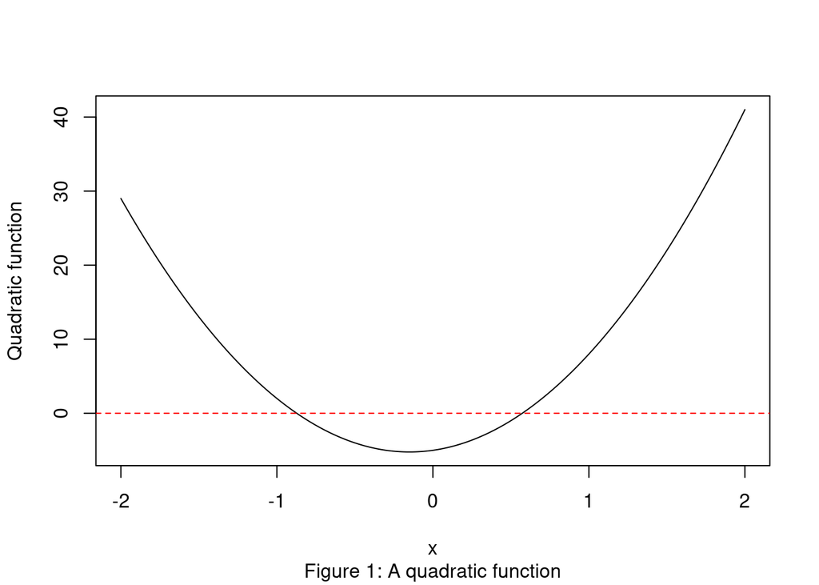

## Studying the Cricket dataset

We will study the cricket dataset more closely now. The battingbowling.csv file in your repository contains information regarding various potential all-rounders in men’s ODI cricket. The players’ batting average, bowling average, and team is present in the dataset.

We will make a few visualizations. But first, we will need a few libraries.

```r
library(ggplot2)
library(tibble)
```

Let’s load the data the data and convert it to a tibble.

```r
cric <- read.csv("battingbowling.csv")
cric <- as_tibble(cric)
cric
```

```
## # A tibble: 78 × 4
##    X              Bowling Batting Team
##    <chr>            <dbl>   <dbl> <chr>
##  1 Khalil Ahmed      31      4.5  India
##  2 Jasprit Bumrah    24.4   13.8  India
##  3 Y Chahal          28.8    8.16 India
##  4 R Jadeja          36.6   31.9  India
##  5 K Jadhav          37.8   42.1  India
##  6 V Kohli           66.2   59.3  India
##  7 K Yadav           26.2   13.1  India
##  8 B Kumar           34.6   14.2  India
##  9 M Shami           25.4    3.73 India
## 10 H Pandya          40.6   29.9  India
## # … with 68 more rows
```

Let’s create a side-by-side boxplot of the Batting averages:

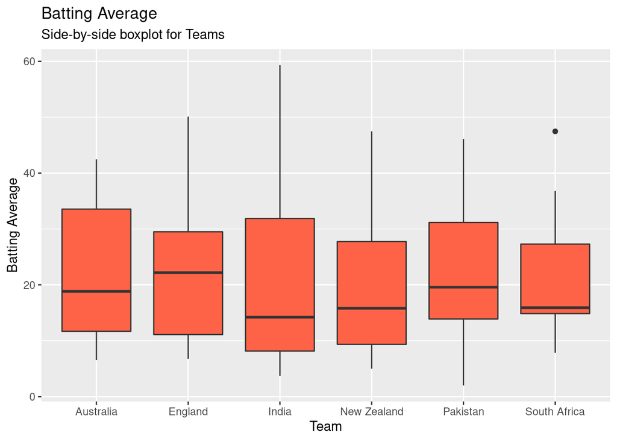

```r
p <- ggplot(cric, aes(x = Team,y = Batting))
p + geom_boxplot(fill = "tomato")+
labs(title = "Batting Average",
subtitle = "Side-by-side boxplot for Teams",
y = "Batting Average")
```